# Downloading and Processing Data

Yujin Choi

2023-02-28

# I. Project Hypothesis and Details

**Hypothesis:** Genes differentially expressed across old populations have significant overlap with HGPS compared to the young population. [[1]](https://genomebiology.biomedcentral.com/articles/10.1186/s13059-018-1599-6)

**Dataset:** RNA-seq data of fibroblast cell lines of a wide-range of ages as well as from HGPS patients. [[GEO]](https://www.ncbi.nlm.nih.gov/geo/query/acc.cgi?acc=GSE113957) [[SRA]](https://www.ncbi.nlm.nih.gov/Traces/study/?acc=PRJNA454681)

- 10 samples (<10yo), 10 samples (>80yo), 10 samples (HGPS)

**Technical Problems:** Some of these reads are done through different Illumina sequencing platforms (HiSeq 2500 and NextSeq 500) which potentially can cause variability. There are no technical replicants between these two platforms. There might also be biases in the data as most of the samples are Caucasian and also samples are from different skin locations.

**Additional Information:**

- Data generated by Salk Institute for Biological Studies [[1]](https://genomebiology.biomedcentral.com/articles/10.1186/s13059-018-1599-6) [[GEO]](https://www.ncbi.nlm.nih.gov/geo/query/acc.cgi?acc=GSE113957) [[SRA]](https://www.ncbi.nlm.nih.gov/Traces/study/?acc=PRJNA454681)
- Human dermal fibroblasts with three conditions: young (<10yo), old (>80yo), and HGPS patients.
- Used Illumina TruSeq Stranded mRNA kit which uses Poly-A selection
- Single-end Stranded RNA-Seq; read lengths usually 75 bp, but a few are 51 bp
- The paper aligned to HG19 Human Genome with STAR but I will alighn to HG38

# II. Accession List for PRJNA454681

Exploring the Accession List for PRJNA454681 and extracting the SRR numbers of samples we would like to look at.

```r
young=`awk -F ',' '$2<10 {print $1}' SRA_run_selector.txt | head -n 10`
old=`awk -F ',' '$2>80 {print $1}' SRA_run_selector.txt | head -n 11 | tail -n +2`
hgps=`awk -vFPAT='([^,]*)|("[^"]+")' -vOFS=, '$15 == "HGPS" {print $1}' SRA_run_selector.txt`
srr=`echo $young $old $hgps`
```

[output not shown]

Made sure that these samples all have a read length of `75bp` and are run on `NextSeq 500`.

# III. Download FASTQ, FASTA, and GTF

Next, we download one of the sample `fastq` files from SRA. We also download the `fasta` reference genome (GRCh38.p13) and the `gtf` gene annotation (version 109) from ENSEMBL.

```r
srun -n1 --pty --partition=angsd_class --mem=10G bash -i

curl -L ftp://ftp.sra.ebi.ac.uk/vol1/fastq/SRR709/009/SRR7093809/SRR7093809.fastq.gz -o /athena/angsd/scratch/yuc4017/fastq/SRR7093809.fastq.gz

wget -P /athena/angsd/scratch/yuc4017/genome/ 'ftp://ftp.ensembl.org/pub/release-109/fa
sta/homo_sapiens/dna/Homo_sapiens.GRCh38.dna_sm.primary_assembly.fa.gz'

wget -P /athena/angsd/scratch/yuc4017/genome/ 'ftp://ftp.ensembl.org/pub/release-109/gtf/homo_sapiens/Homo_sapiens.GRCh38.109.gtf.gz'

cd /athena/angsd/scratch/yuc4017/genome/
gzip -d Homo_sapiens.GRCh38.109.gtf.gz
gzip -d Homo_sapiens.GRCh38.dna_sm.primary_assembly.fa.gz
```

These were ran in an interactive session but in hindsight it would have been better to submit them as separate batch jobs to download concurrently.

# IV. Build Index and Align Sample

Used a bash script to index the reference genome with `STAR` with the parameter set to `--sjdbOverhang 74`.

```r
#!/bin/bash -l
#SBATCH --partition=angsd_class
#SBATCH --nodes=1
#SBATCH --ntasks=1
#SBATCH --job-name="genome_index"
#SBATCH --time=10:0:00 # HH/MM/SS
#SBATCH --mem=50G # memory requested, units available: K,M,G,T
#SBATCH --mail-user=yuc4017@med.cornell.edu
#SBATCH --mail-type=ALL
#SBATCH --requeue

mamba activate angsd

STAR --runMode genomeGenerate --runThreadN 1 \
        --genomeDir /athena/angsd/scratch/yuc4017/genome/index \
        --genomeFastaFiles /athena/angsd/scratch/yuc4017/genome/Homo_sapiens.GRCh38.dna_sm.primary_assembly.fa \
        --sjdbGTFfile /athena/angsd/scratch/yuc4017/genome/Homo_sapiens.GRCh38.109.gtf \
        --sjdbOverhang 74
```

Used a bash script to `fastqc` the reads of sample `SRR7093809.fastq.gz`. The `fastqc` results show that the quality of the reads are fairly good as seen in Figure 1 below. There are no adapter contaminations either. Then, aligned with `STAR` to the reference genome. `samtools` is used to index the aligned read.

```r
#!/bin/bash -l
#SBATCH --partition=angsd_class
#SBATCH --nodes=1
#SBATCH --ntasks=1
#SBATCH --job-name="align-fastqc"
#SBATCH --time=10:0:00 # HH/MM/SS
#SBATCH --mem=40G # memory requested, units available: K,M,G,T
#SBATCH --mail-user=yuc4017@med.cornell.edu
#SBATCH --mail-type=ALL
#SBATCH --requeue

mamba activate angsd

fastqc -o /athena/angsd/scratch/yuc4017/fastqc "/athena/angsd/scratch/yuc4017/fastq/SRR7093809.fastq.gz" --extract

STAR --runMode alignReads \
  --runThreadN 1 \
  --genomeDir /athena/angsd/scratch/yuc4017/genome/index \
  --readFilesIn /athena/angsd/scratch/yuc4017/fastq/SRR7093809.fastq.gz \
  --readFilesCommand zcat \
  --outFileNamePrefix /athena/angsd/scratch/yuc4017/alignments/SRR7093809. \
  --outSAMtype BAM SortedByCoordinate

samtools index /athena/angsd/scratch/yuc4017/alignments/SRR7093809.Aligned.sortedByCoord.out.bam
```

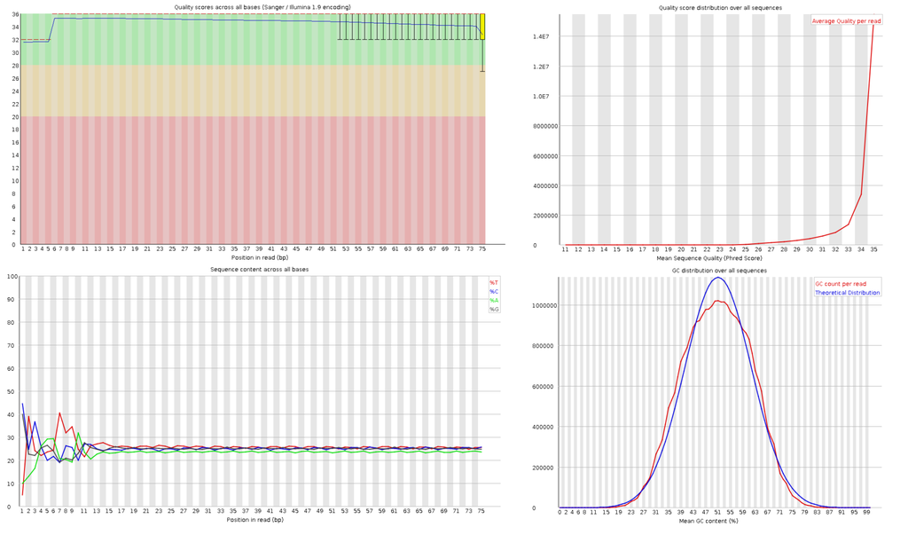

*Fig. 1. FastQC results for Sample SRR7093809: Quality Scores, Sequence Content, GC Distribution*

Ran `multiqc` and `bamqc` on the aligned read. There were 93.9% uniquely mapped aligned reads. There are 5.7% mapped to multiple loci, 0.1% mapped to too many loci and 0.3% unmapped due to read being too short. The alignment was successful.

```r
multiqc -o multiqc/ alignments/
/softlib/apps/EL7/BamQC/bin/bamqc -o bamqc alignments/SRR7093809.Aligned.sortedByCoord.out.bam
```

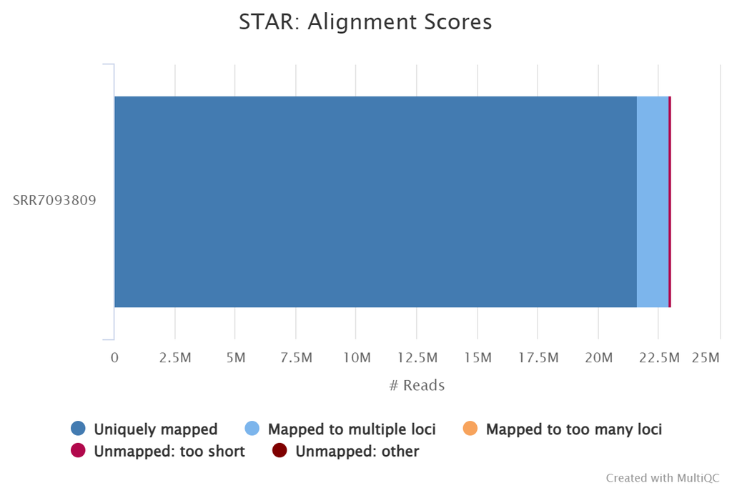

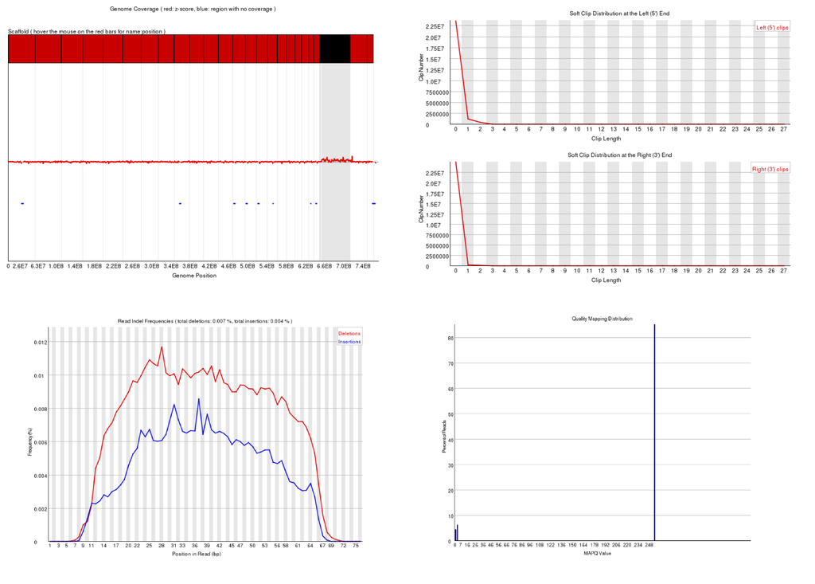

*Fig. 3. BamQC results for STAR alignment: Genome Coverage, Soft Clip Distributions, Indel Frequencies, and Mapping Quality Distribution.*

I ran `STAR` alignment on the default parameters. The `BamQC` and `MultiQC` for this alignment turned out fairly well. However, going forward, I might be adjusting some of the parameters. Notably: `--alignIntronMin 1` and `--alignIntronMax 1300000` These numbers were found from the BED file for `GRCh38.hg38 track GENCODE V43` from the UCSC Genome table browser.

```r
awk '{print $3 - $2} ' Downloads/bed.txt | sort -n | uniq | head -n 3
```

```
1
2
3
```

```r
awk '{print $3 - $2} ' Downloads/bed.txt | sort -rn | uniq | head -n 3
```

```
1240120
1160411
1136472
```

# V. Download and Align All Samples

Will use a bash script to download the remaining 29 samples and `fastqc` each. Then, the script will `STAR` align each sample to the indexed reference genome. I haven’t run the bash scrip yet to save resources for now (and I’m also wondering if I should download each sample into different folders for each sample type: young, old, HGPS).

```r
#!/bin/bash -l
#SBATCH --partition=angsd_class
#SBATCH --nodes=1
#SBATCH --ntasks=1
#SBATCH --job-name="download"
#SBATCH --time=7:0:00 # HH/MM/SS
#SBATCH --mem=50G # memory requested, units available: K,M,G,T
#SBATCH --mail-user=yuc4017@med.cornell.edu
#SBATCH --mail-type=ALL
#SBATCH --requeue
#SBATCH --output=/home/yuc4017/slurm/slurm-%j.out

IFS=" "
SRR_IDS=$(cat SRR_accession_IDs.txt)
read -a SRR_IDS <<< $(cat SRR_accession_IDs.txt)

mamba activate angsd

for ID in "${SRR_IDS[@]}"; do
        echo "==================================="
        echo "Now downloading sample ${ID}"
        if [ ! -r  /athena/angsd/scratch/yuc4017/fastq/${ID}.fastq.gz ]; then
                url="ftp://ftp.sra.ebi.ac.uk/vol1/fastq/SRR709/00${ID: -1}/${ID}/${ID}.fastq.gz"
                echo $url
                curl -L $url -o /athena/angsd/scratch/yuc4017/fastq/${ID}.fastq.gz
        fi
done

for file in /athena/angsd/scratch/yuc4017/fastq/*.fastq.gz; do
        echo "==================================="
        ID=`echo $file | egrep -o 'SRR[0-9]*'`
        echo "FastQC on ${ID}"
        if [ ! -r  /athena/angsd/scratch/yuc4017/fastqc/${ID}_fastqc.html ]; then
                fastqc -o /athena/angsd/scratch/yuc4017/fastqc/ "$file" --extract;
                echo  "/athena/angsd/scratch/yuc4017/fastqc/${ID}_fastqc.html"
        fi
        echo "==================================="
        echo "Alignment on ${ID}"
        if [ ! -r  /athena/angsd/scratch/yuc4017/alignments/${ID}.Log.final.out ]; then
                STAR --runMode alignReads \
                        --runThreadN 1 \
                        --alignIntronMin 1\
                        --alignIntronMax 1300000\
                        --genomeDir /athena/angsd/scratch/yuc4017/genome/index \
                        --readFilesIn /athena/angsd/scratch/yuc4017/fastq/${ID}.fastq.gz \
                        --readFilesCommand zcat \
                        --outFileNamePrefix /athena/angsd/scratch/yuc4017/alignments/${ID}. \
                        --outSAMtype BAM SortedByCoordinate

                samtools index /athena/angsd/scratch/yuc4017/alignments/${ID}.Aligned.sortedByCoord.out.bam
                echo  "/athena/angsd/scratch/yuc4017/alignments/${ID}.Aligned.sortedByCoord.out.bam.bai"
        fi
done
```

```r
multiqc -o /athena/angsd/scratch/yuc4017/multiqc/all_fastqc/ /athena/angsd/scratch/yuc4017/fastqc/
scp yuc4017@aphrodite.med.cornell.edu:/athena/angsd/scratch/yuc4017/multiqc/all_fastqc/multiqc_report.html .
```